# Population growth and income growth in the United States by Sam Lewis

# Intro/Data collection and Data processing

For my project, I will focus on the income growth trends in the United States, and seeing how population growth affects that. My main data set is [NCS data](https://www.census.gov/data/tables/time-series/demo/popest/2020s-national-total.html) from the census bureau website, which shows states population by year. Using this, I can compute growth from year to year, and compare them by both region and state. Aditionally, I can use [ACS data](https://data.census.gov/table/ACSDT1Y2023.B19301?q=b19301&g=010XX00US$0400000), which shows average household income by state, to break down how different states are doing econonically, and compare this to population growth. This is important since knowing the driving factors behind income growth can help us set good policy, and can help us focus on growing peoples per capita income. States with high growth rates can be used as models for states with low growth rates.

First, I need to link my google drive, since it is where I have all my data downloaded. Then, I need to load in the data sets from my drive.

```python
from google.colab import drive
drive.mount('/content/drive')
##mount google drive
```

link to github page https://slewis3418.github.io/Copy_of_milestone_2.html

Below, I have read in my data for population,, and we can see a data frame, breaking the data down by the whole country, as well as by region and state. For my project, we will be using data at the state level for the years 2023 and 2021. I am choosing 2023 since it is the most recent time I am able to find data on income at the time of writing this, and 2021 since I would like to explore how states have recovered post COVID.

```python
import pandas as pd
df_NST = pd.read_csv("/content/drive/My Drive/NST-EST2024-ALLDATA.csv")
df_NST.head()
df_NST
##import first data set
```

|  | SUMLEV | REGION | DIVISION | STATE | NAME | ESTIMATESBASE2020 | POPESTIMATE2020 | POPESTIMATE2021 | POPESTIMATE2022 | POPESTIMATE2023 | ... | RINTERNATIONALMIG2023 | RINTERNATIONALMIG2024 | RDOMESTICMIG2021 | RDOMESTICMIG2022 | RDOMESTICMIG2023 | RDOMESTICMIG2024 | RNETMIG2021 | RNETMIG2022 | RNETMIG2023 | RNETMIG2024 |
| --- | --- | --- | --- | --- | --- | --- | --- | --- | --- | --- | --- | --- | --- | --- | --- | --- | --- | --- | --- | --- | --- |
| 0 | 10 | 0 | 0 | 0 | United States | 331515736 | 331577720 | 332099760 | 334017321 | 336806231 | ... | 6.840246 | 8.231786 | 0.000000 | 0.000000 | 0.000000 | 0.000000 | 1.133093 | 5.084797 | 6.840246 | 8.231786 |
| 1 | 20 | 1 | 0 | 0 | Northeast Region | 57617706 | 57431458 | 57252533 | 57159597 | 57398303 | ... | 8.175150 | 9.848371 | -4.674375 | -7.824957 | -4.857718 | -3.334322 | -3.271477 | -2.006798 | 3.317432 | 6.514050 |
| 2 | 30 | 1 | 1 | 0 | New England | 15122011 | 15057350 | 15118145 | 15175633 | 15263573 | ... | 8.005202 | 9.622685 | 2.416795 | -2.957175 | -2.067991 | -1.575091 | 4.188365 | 4.325839 | 5.937211 | 8.047594 |
| 3 | 30 | 1 | 2 | 0 | Middle Atlantic | 42495695 | 42374108 | 42134388 | 41983964 | 42134730 | ... | 8.236647 | 9.930153 | -7.206423 | -9.578005 | -5.867209 | -3.971810 | -5.935167 | -4.287388 | 2.369438 | 5.958342 |
| 4 | 20 | 2 | 0 | 0 | Midwest Region | 68998970 | 68984258 | 68872831 | 68903297 | 69186401 | ... | 4.859117 | 5.861482 | -2.502867 | -2.649762 | -1.300416 | -0.709222 | -1.700819 | 0.891824 | 3.558701 | 5.152260 |
| ... | ... | ... | ... | ... | ... | ... | ... | ... | ... | ... | ... | ... | ... | ... | ... | ... | ... | ... | ... | ... | ... |
| 61 | 40 | 4 | 9 | 53 | Washington | 7707586 | 7727209 | 7743760 | 7794123 | 7857320 | ... | 8.570200 | 10.316588 | -2.028057 | -0.444333 | -2.209764 | 0.337770 | -0.219379 | 5.160549 | 6.360436 | 10.654358 |
| 62 | 40 | 3 | 5 | 54 | West Virginia | 1793736 | 1791646 | 1785618 | 1774122 | 1770495 | ... | 1.309027 | 1.604870 | 1.668314 | 0.162371 | 1.859721 | 2.553330 | 2.074770 | 1.102328 | 3.168749 | 4.158200 |
| 63 | 40 | 2 | 3 | 55 | Wisconsin | 5894170 | 5897375 | 5881608 | 5903975 | 5930405 | ... | 3.083727 | 3.724715 | -3.158677 | 1.273081 | 1.298758 | 1.064973 | -2.617204 | 4.614960 | 4.382486 | 4.789688 |
| 64 | 40 | 4 | 8 | 56 | Wyoming | 576844 | 577681 | 579636 | 581978 | 585067 | ... | 1.777138 | 2.191552 | 3.126196 | 4.216547 | 2.983604 | 1.468425 | 3.362951 | 5.165227 | 4.760742 | 3.659977 |
| 65 | 40 | X | X | 72 | Puerto Rico | 3285874 | 3281590 | 3262711 | 3220137 | 3203792 | ... | -0.016812 | 4.745995 | 0.000000 | 0.000000 | 0.000000 | 0.000000 | -1.319316 | -8.681678 | -0.016812 | 4.745995 |

66 rows × 75 columns

We need to load in ACS data as well so we can account for change in income

```python
acs2023 = pd.read_csv("/content/drive/My Drive/ACS2023.csv")
acs2023
acs2021 = pd.read_csv("/content/drive/My Drive/ACS2021.csv")
acs2021
##load in data frame drop unnamed columns, and check.
acs2023 = acs2023.drop(columns=['Unnamed: 4'])
acs2021 = acs2021.drop(columns=['Unnamed: 4'])
acs2023.head()
acs2021.head()
```

|  | GEO_ID | NAME | B19013_001E | B19013_001M |
| --- | --- | --- | --- | --- |
| 0 | Geography | Geographic Area Name | Estimate!!Median household income in the past ... | Margin of Error!!Median household income in th... |
| 1 | 0400000US01 | Alabama | 53913 | 781 |
| 2 | 0400000US02 | Alaska | 77845 | 2148 |
| 3 | 0400000US04 | Arizona | 69056 | 686 |
| 4 | 0400000US05 | Arkansas | 52528 | 1002 |

# Calculating percent change

Calculating the data in terms of percent change allows us to see growth trends, and gives us a uniform scale we can use for modeling later in the project. Aditionally, I calculated variable that accounts for states in the northeast, as an example for percent change, just so we can check and make sure all of our data is correct.

```python
percent_change = ((df_NST['POPESTIMATE2023'] - df_NST['POPESTIMATE2021'])/df_NST['POPESTIMATE2021'])*100
percent_change.describe()
```

|  | 0 |
| --- | --- |
| count | 66.000000 |
| mean | 1.225981 |
| std | 1.295592 |
| min | -1.805830 |
| 25% | 0.348190 |
| 50% | 0.949175 |
| 75% | 2.175937 |
| max | 4.914444 |

**dtype:** float64

I created an indicator for states in the north east, that way we can see our percent change variable amongst only states in the north east.

```python
percent_change = ((df_NST['POPESTIMATE2023'] - df_NST['POPESTIMATE2021']) / df_NST['POPESTIMATE2021']) * 100
##percent change calculation
df_NST['percent_change'] = percent_change
northeast_states = df_NST[
    (df_NST['NAME'] == 'Connecticut') |
    (df_NST['NAME'] == 'Maine') |
    (df_NST['NAME'] == 'Massachusetts') |
    (df_NST['NAME'] == 'New Hampshire') |
    (df_NST['NAME'] == 'Rhode Island') |
    (df_NST['NAME'] == 'Vermont') |
    (df_NST['NAME'] == 'New Jersey') |
    (df_NST['NAME'] == 'New York') |
    (df_NST['NAME'] == 'Pennsylvania')
]
northeast_states.head()
##filter set and just look at northeast states
```

|  | SUMLEV | REGION | DIVISION | STATE | NAME | ESTIMATESBASE2020 | POPESTIMATE2020 | POPESTIMATE2021 | POPESTIMATE2022 | POPESTIMATE2023 | ... | RINTERNATIONALMIG2024 | RDOMESTICMIG2021 | RDOMESTICMIG2022 | RDOMESTICMIG2023 | RDOMESTICMIG2024 | RNETMIG2021 | RNETMIG2022 | RNETMIG2023 | RNETMIG2024 | percent_change |
| --- | --- | --- | --- | --- | --- | --- | --- | --- | --- | --- | --- | --- | --- | --- | --- | --- | --- | --- | --- | --- | --- |
| 20 | 40 | 1 | 1 | 9 | Connecticut | 3607701 | 3579918 | 3606607 | 3617925 | 3643023 | ... | 9.897115 | 5.400663 | -2.880740 | -1.779933 | -1.656169 | 7.130289 | 3.307896 | 6.474637 | 8.240946 | 1.009702 |
| 33 | 40 | 1 | 1 | 23 | Maine | 1363196 | 1364571 | 1378931 | 1390922 | 1399646 | ... | 3.705265 | 13.133579 | 10.382500 | 6.878886 | 3.800107 | 13.871322 | 12.732806 | 9.944212 | 7.505371 | 1.502251 |
| 35 | 40 | 1 | 1 | 25 | Massachusetts | 7033132 | 6994598 | 7000474 | 7022468 | 7066568 | ... | 12.704169 | -2.102597 | -7.821896 | -5.191555 | -3.869676 | 0.251803 | 2.574210 | 5.399660 | 8.834493 | 0.944136 |
| 43 | 40 | 1 | 1 | 33 | New Hampshire | 1377546 | 1378756 | 1387677 | 1396678 | 1402199 | ... | 3.052044 | 6.165340 | 7.190893 | 3.194138 | 3.478192 | 7.280133 | 8.295638 | 5.680850 | 6.530235 | 1.046497 |
| 44 | 40 | 1 | 2 | 34 | New Jersey | 9289014 | 9272794 | 9270541 | 9295227 | 9379642 | ... | 13.844130 | -3.519108 | -7.192700 | -5.156448 | -3.766215 | -1.928995 | 0.661432 | 6.403793 | 10.077915 | 1.176857 |

5 rows × 76 columns

# Graphs and statistics/EDA

```python
acs2021['B19013_001E'] = pd.to_numeric(acs2021['B19013_001E'], errors='coerce')
acs2023['B19013_001E'] = pd.to_numeric(acs2023['B19013_001E'], errors='coerce')
```

In order to merge, we need to make sure are variable is numberic. Below, we can see the merge and begin modeling

```python
## merge ACS 2021 and 2023 on state name, keeping only median household column.
merged = acs2021[['NAME', 'B19013_001E']].merge(
    acs2023[['NAME', 'B19013_001E']],
    on='NAME',
    suffixes=('_2021', '_2023')
)
## Calculate the percent change in median household income from 2021 to 2023.

merged['income_change'] = (
    merged['B19013_001E_2023'] - merged['B19013_001E_2021']
) / merged['B19013_001E_2021']
merged.head()
```

|  | NAME | B19013_001E_2021 | B19013_001E_2023 | income_change |
| --- | --- | --- | --- | --- |
| 0 | Geographic Area Name | NaN | NaN | NaN |
| 1 | Alabama | 53913.0 | 62212.0 | 0.153933 |
| 2 | Alaska | 77845.0 | 86631.0 | 0.112865 |
| 3 | Arizona | 69056.0 | 77315.0 | 0.119599 |
| 4 | Arkansas | 52528.0 | 58700.0 | 0.117499 |

```python
##drop the first row in the data frame
acs2023_2 = acs2023.iloc[1:].copy()
##take just the name from the state file, drop all - and ' which surrond some of the state names.
## Aditionally, change the name of the variable NAME to state so it is consitent throught both data sets, alloing a merge
acs2023_2['State'] = acs2023['NAME'].str.replace(r' -.*', '', regex=True).str.strip()
##convert to numerica and change b19013 to median income, and keep only state and median income since that is all we need for merge.
acs2023_2['MedianIncome'] = pd.to_numeric(acs2023['B19013_001E'], errors='coerce')
acs2023_2 = acs2023_2[['State', 'MedianIncome',]]
```

```python
##filter to only include state level data
df_NST_2 = df_NST[df_NST['SUMLEV'] == 40].copy()
##once again change name to state
df_NST_2['State'] = df_NST['NAME'].str.strip()
##keep only relevant columns, calculate percent change
df_NST_2 = df_NST_2[['State', 'POPESTIMATE2023','POPESTIMATE2021']]
df_NST_2['PercentChangePop'] = ((df_NST_2['POPESTIMATE2023'] - df_NST_2['POPESTIMATE2021']) / df_NST_2['POPESTIMATE2021']) * 100
```

Before I make more graphs, I need to clean the ACS data, by dropping the - state in the names, in order to merge the data sets together, as well as convert median income into a float. Additionally, need to make sure I keep only states, and not the random regions in the data set. This is all done above.

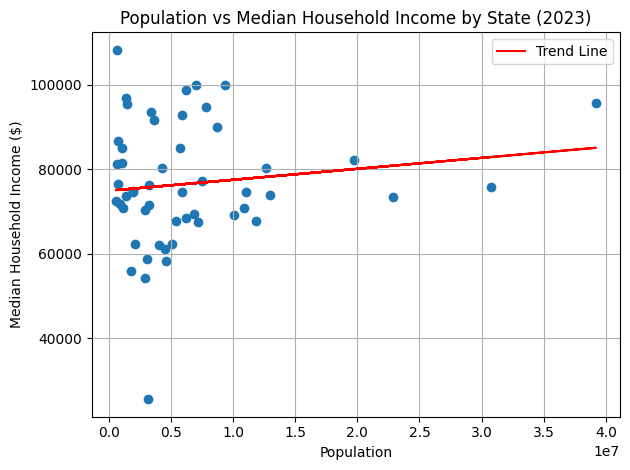

```python
import pandas as pd
import numpy as np
import matplotlib.pyplot as plt


##merge pop and income data on inner join, drop rows with missing values
merged_df = pd.merge(df_NST_2, acs2023_2, on='State', how='inner')
merged_df.dropna(inplace=True)



merged_df.head()
##define x and y variable, line of least square fit
x = merged_df['POPESTIMATE2023']
y = merged_df['MedianIncome']
m, b = np.polyfit(x, y, 1)

##plot and add titles

plt.scatter(x, y)
plt.plot(x, m * x + b, color='red', label='Trend Line')
plt.title("Population vs Median Household Income by State (2023)")
plt.xlabel("Population")
plt.ylabel("Median Household Income ($)")
plt.grid(True)
plt.legend()
plt.tight_layout()
plt.show()
```

The above graph shows the relation between population and median household income in a state, as well as trend line which highlights a slight positive relation between the values. Intuitively, we would expect larger states to have higher income per capita due to urbanization and economic developemnt, however many small states on the left have higher income per capita. In fact we notice a trend of bunching on the left. We can also see that the relationship is not very strong.

```python
merged['State'] = merged['NAME'].str.strip()
##antoher merge, this time on percent change rather than raw numbers
merged_percent = merged.merge(df_NST_2[['State', 'PercentChangePop']], on='State', how='inner')
merged_percent.dropna(inplace=True)
merged_percent.head()
```

|  | NAME | B19013_001E_2021 | B19013_001E_2023 | income_change | State | PercentChangePop |
| --- | --- | --- | --- | --- | --- | --- |
| 0 | Alabama | 53913.0 | 62212.0 | 0.153933 | Alabama | 1.356196 |
| 1 | Alaska | 77845.0 | 86631.0 | 0.112865 | Alaska | 0.284578 |
| 2 | Arizona | 69056.0 | 77315.0 | 0.119599 | Arizona | 2.735041 |
| 3 | Arkansas | 52528.0 | 58700.0 | 0.117499 | Arkansas | 1.407163 |
| 4 | California | 84907.0 | 95521.0 | 0.125007 | California | 0.143394 |

Also create a merge that uses percent change, that way we can recreate the graph with percent change in population and income.

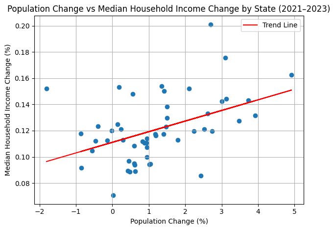

```python
import pandas as pd
import numpy as np
import matplotlib.pyplot as plt



##again define x and y, this time for percent change

x = merged_percent['PercentChangePop']
y = merged_percent['income_change']


##another line of best fit
m, b = np.polyfit(x, y, 1)
##plot
plt.scatter(x, y)
plt.plot(x, m * x + b, color='red', label='Trend Line')
plt.title("Population Change vs Median Household Income Change by State (2021–2023)")
plt.xlabel("Population Change (%)")
plt.ylabel("Median Household Income Change (%)")
plt.grid(True)
plt.legend()
plt.tight_layout()
plt.show()
```

In this graph, we can see that the trend line is stronger than the previous graph, and that percent population change is a better predictor than population change. We can assume that this is because people would prefer to move to a state where income is growing over time, driving up population growth. Since this is a stronger relationship, I would prefer to use it to build a model over just median income and population.

```python
#map each state to a region that is consistent with what region they are classified as in census data
state_to_region = {
    'Alabama': 'South', 'Arkansas': 'South', 'Florida': 'South', 'Georgia': 'South',
    'Kentucky': 'South', 'Louisiana': 'South', 'Mississippi': 'South',
    'North Carolina': 'South', 'South Carolina': 'South', 'Tennessee': 'South',
    'Virginia': 'South', 'West Virginia': 'South', 'Delaware': 'South', 'Maryland': 'South',
    'District of Columbia': 'South', 'Oklahoma': 'South', 'Texas': 'South',
    'Connecticut': 'Northeast', 'Maine': 'Northeast', 'Massachusetts': 'Northeast',
    'New Hampshire': 'Northeast', 'Rhode Island': 'Northeast', 'Vermont': 'Northeast',
    'New Jersey': 'Northeast', 'New York': 'Northeast', 'Pennsylvania': 'Northeast',
    'Illinois': 'Midwest', 'Indiana': 'Midwest', 'Iowa': 'Midwest', 'Kansas': 'Midwest',
    'Michigan': 'Midwest', 'Minnesota': 'Midwest', 'Missouri': 'Midwest', 'Nebraska': 'Midwest',
    'North Dakota': 'Midwest', 'Ohio': 'Midwest', 'South Dakota': 'Midwest', 'Wisconsin': 'Midwest',
    'Alaska': 'West', 'Arizona': 'West', 'California': 'West', 'Colorado': 'West',
    'Hawaii': 'West', 'Idaho': 'West', 'Montana': 'West', 'Nevada': 'West',
    'New Mexico': 'West', 'Oregon': 'West', 'Utah': 'West', 'Washington': 'West', 'Wyoming': 'West'
}
```

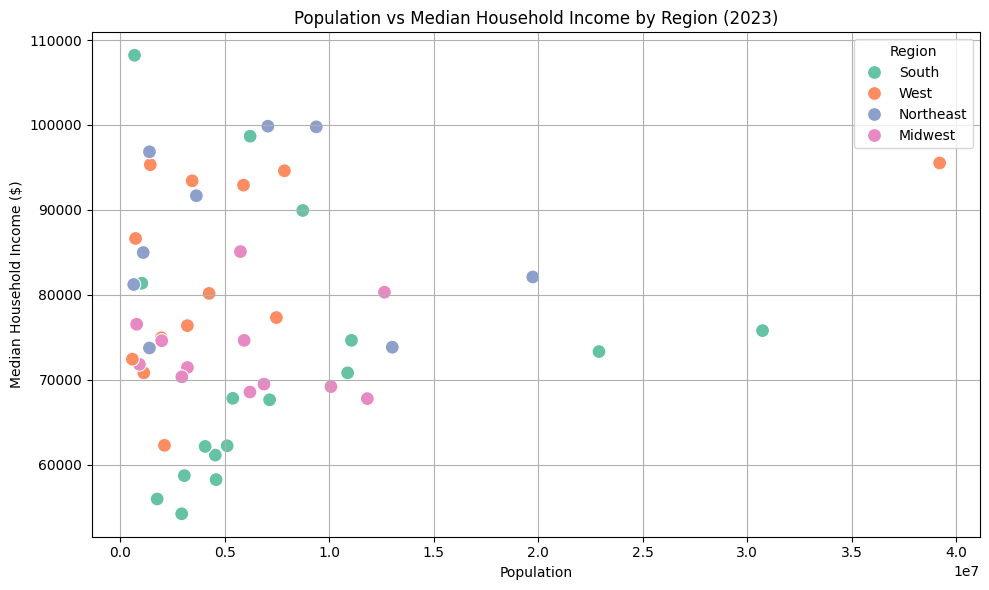

```python
##maps each state to its region based off the dictionary above

merged_df['Region'] = merged_df['State'].map(state_to_region)
import seaborn as sns
import matplotlib.pyplot as plt
##set figure size and plot
plt.figure(figsize=(10, 6))
sns.scatterplot(
    data=merged_df,
    x='POPESTIMATE2023',
    y='MedianIncome',
    hue='Region',
    palette='Set2',
    s=100,
)

plt.title("Population vs Median Household Income by Region (2023)")
plt.xlabel("Population")
plt.ylabel("Median Household Income ($)")
plt.grid(True)
plt.tight_layout()
plt.show()
```

In this, we can see some income clustering based on region. We see that the south tends to cluster are a lower median income, the northeast tends to cluster towards the top, and the west and midwest fall in the middle.

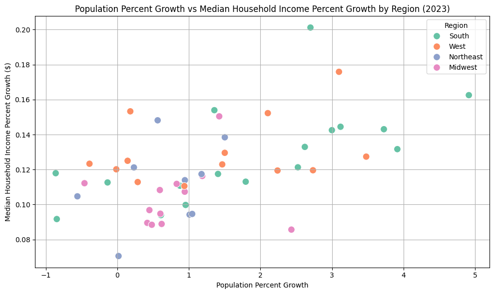

```python
merged_percent['Region'] = merged_df['State'].map(state_to_region)
import seaborn as sns
import matplotlib.pyplot as plt
##same as above, this time for income and population growth though.
plt.figure(figsize=(10, 6))
sns.scatterplot(
    data=merged_percent,
    x='PercentChangePop',
    y='income_change',
    hue='Region',
    palette='Set2',
    s=100,
)

plt.title("Population Percent Growth vs Median Household Income Percent Growth by Region (2023)")
plt.xlabel("Population Percent Growth")
plt.ylabel("Median Household Income Percent Growth ($)")
plt.grid(True)
plt.tight_layout()
plt.show()
```

Interestingly, it seems that the south is seeing some of the highest rates of population and income growth, despite being some of the poorest states. The midwest seems to be somewhat clustered around low population growth, and lower income growth, and the west and northeast are a bit more scattered.

```python
##group together, and calculate median income and pop estimate by region
region_medians = merged_df.groupby('Region')[['POPESTIMATE2023', 'MedianIncome']].median().reset_index()
region_medians
##compute median percent change by region
region_medians_percent = merged_percent.groupby('Region')[['PercentChangePop', 'income_change']].median().reset_index()
region_medians_percent
```

|  | Region | PercentChangePop | income_change |
| --- | --- | --- | --- |
| 0 | Midwest | 0.610190 | 0.102077 |
| 1 | Northeast | 0.944136 | 0.113927 |
| 2 | South | 1.794582 | 0.121291 |
| 3 | West | 1.466471 | 0.123325 |

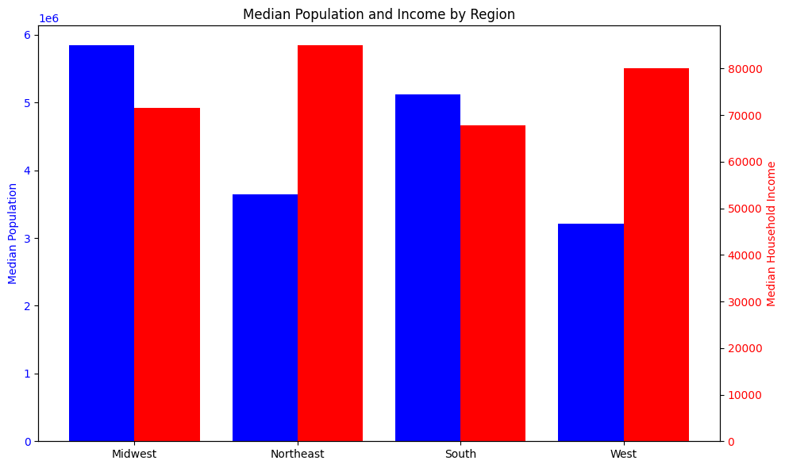

```python
import matplotlib.pyplot as plt

fig, ax1 = plt.subplots(figsize=(10, 6))
##position bars, could not get it to work without doing this
x_pos = np.arange(len(region_medians['Region']))
x = region_medians['Region']
bar_width = 0.4
##plot median pop bars on the left
ax1.bar(x_pos - bar_width/2, region_medians['POPESTIMATE2023'], width=bar_width, label='Population', color='blue')
ax1.set_ylabel('Median Population', color='blue')
ax1.tick_params(axis='y', labelcolor='blue')
##plot median household income on the right
ax2 = ax1.twinx()
ax2.bar(x_pos + bar_width/2, region_medians['MedianIncome'], width=bar_width, label='Median Income', color='red')
ax2.set_ylabel('Median Household Income', color='red')
ax2.tick_params(axis='y', labelcolor='red')
##set region names and add titles
ax1.set_xticks(x_pos)
ax1.set_xticklabels(x)
plt.title('Median Population and Income by Region')
plt.tight_layout()
plt.show()
```

A bar graph to farther illustrate what we previously saw on the scatter plot.

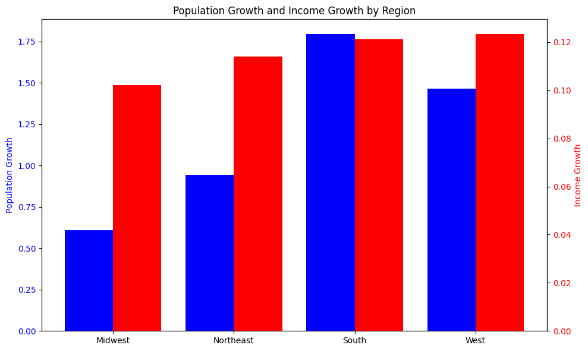

```python
import matplotlib.pyplot as plt
## same thing as above, this time for growth
fig, ax1 = plt.subplots(figsize=(10, 6))
x_pos = np.arange(len(region_medians_percent['Region']))
x = region_medians_percent['Region']
bar_width = 0.4

ax1.bar(x_pos - bar_width/2, region_medians_percent['PercentChangePop'], width=bar_width, label='Population', color='blue')
ax1.set_ylabel('Population Growth', color='blue')
ax1.tick_params(axis='y', labelcolor='blue')

ax2 = ax1.twinx()
ax2.bar(x_pos + bar_width/2, region_medians_percent['income_change'], width=bar_width, label='Median Income', color='red')
ax2.set_ylabel('Income Growth', color='red')
ax2.tick_params(axis='y', labelcolor='red')

ax1.set_xticks(x_pos)
ax1.set_xticklabels(x)
plt.title('Population Growth and Income Growth by Region')
plt.tight_layout()
plt.show()
```

Once again, this reflects one of our previous scatter plots, and is consistent with our findings.

# Merging in education

Since the relation is relativly weak, I am going to merge in more data to try to find a stronger relationship. The following data shows percent of people who have a bachelor degree in a state. Once again, this data is ACS data from the Census Buerau. https://data.census.gov/table/ACSST1Y2021.S1501?q=S1501&g=010XX00US

```python
##load in data
df_education_2021 = pd.read_csv("/content/drive/My Drive/ACSST1Y2021.S1501-Data.csv")
df_education_2023 = pd.read_csv("/content/drive/My Drive/ACSST1Y2023.S1501-Data.csv")
df_education_2023
df_education_2021
##change name to state to make merging possible, merge together 2021 and 2023
df_education_2021 = df_education_2021.rename(columns={'NAME': 'State'})
df_education_2023 = df_education_2023.rename(columns={'NAME': 'State'})
df_education_2021 = df_education_2021.rename(columns={'S1501_C02_015E': 'Bachelors_rate_2021'})
df_education_2023 = df_education_2023.rename(columns={'S1501_C02_015E': 'Bachelors_rate_2023'})
education_merged = df_education_2021[['State', 'Bachelors_rate_2021']].merge(
    df_education_2023[['State', 'Bachelors_rate_2023']],
    on='State',
    how='inner'
)
```

```python
##convert bachelor rate to numeric, rename, and calculate percent change
education_merged['Bachelors_rate_2021'] = pd.to_numeric(education_merged['Bachelors_rate_2021'], errors='coerce')
education_merged['Bachelors_rate_2023'] = pd.to_numeric(education_merged['Bachelors_rate_2023'], errors='coerce')

education_merged['BachelorsPercentChange'] = (
    (education_merged['Bachelors_rate_2023'] - education_merged['Bachelors_rate_2021']) /
    education_merged['Bachelors_rate_2021']
) * 100
```

```python
#merge with the rest of the data
merged_percent = merged_percent.drop(columns=['BachelorsPercentChange'], errors='ignore')

merged_percent = merged_percent.merge(
    education_merged[['State', 'BachelorsPercentChange']],
    on='State',
    how='inner'
)

merged_percent.head()
```

|  | NAME | B19013_001E_2021 | B19013_001E_2023 | income_change | State | PercentChangePop | Region | BachelorsPercentChange |
| --- | --- | --- | --- | --- | --- | --- | --- | --- |
| 0 | Alabama | 53913.0 | 62212.0 | 0.153933 | Alabama | 1.356196 | South | 5.474453 |
| 1 | Alaska | 77845.0 | 86631.0 | 0.112865 | Alaska | 0.284578 | West | -1.829268 |
| 2 | Arizona | 69056.0 | 77315.0 | 0.119599 | Arizona | 2.735041 | West | 3.395062 |
| 3 | Arkansas | 52528.0 | 58700.0 | 0.117499 | Arkansas | 1.407163 | South | 3.557312 |
| 4 | California | 84907.0 | 95521.0 | 0.125007 | California | 0.143394 | West | 3.591160 |

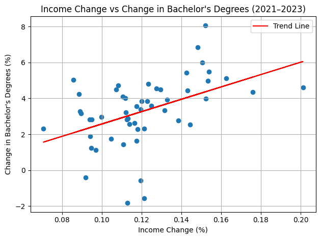

```python
import pandas as pd
import numpy as np
import matplotlib.pyplot as plt



##income change and bachelor degree change, same ploting techniques that were used in the previous plots above.

x = merged_percent['income_change']
y = merged_percent['BachelorsPercentChange']



m, b = np.polyfit(x, y, 1)

plt.scatter(x, y)
plt.plot(x, m * x + b, color='red', label='Trend Line')
plt.title("Income Change vs Change in Bachelor's Degrees (2021–2023)")
plt.xlabel("Income Change (%)")
plt.ylabel("Change in Bachelor's Degrees (%)")
plt.grid(True)
plt.legend()
plt.tight_layout()
plt.show()
```

We see a real, upwards trend, indicating that growth in bachelor degree attainement is a strong predictor of income growth.

# Creating my model

For one model, I am using population growth and bachelor growth rate as my independent variable, and using that to predict income growth, my dependent variable. Additionally, I built a second model that adds in the region varaibles as well. While building a model at the county level might have been useful for increasing the size of my data set, I ultimatly decided to use state level data, since I believe this is better for setting policy, and provides more interesting interpretations. However, the lower number of observations should be noted, since extreme outliers can bias our data heavily. Based off my EDA, I hypothesise that areas with higher growth and education will have higher income growth. The model I am building is a mulit variable linear regression model. This is because there is a somewhat upward linear relation, which is highlighted in my EDA, as well as multiple variables. A linear regression model is also ideal for a smaller data set, like mine, espeically when compared to other models we learned in this class, such as a KNN. Aditionally, classification models would not work well for my data.

# Modeling

```python
from sklearn.model_selection import train_test_split, KFold, cross_val_score
from sklearn.linear_model import LinearRegression
from sklearn.metrics import mean_absolute_error, make_scorer
import numpy as np
import pandas as pd

##x = independent variable, y = depenedent variable

X = merged_percent[['BachelorsPercentChange', 'PercentChangePop']].dropna()
y = merged_percent.loc[X.index, 'income_change']

# split data, train and test
X_train, X_test, y_train, y_test = train_test_split(
    X, y, test_size=0.2, random_state=42
)

# build model, test using k fold
model = LinearRegression()
kf = KFold(n_splits=5, shuffle=True, random_state=42)

mae_scores = -cross_val_score(
    model, X_train, y_train, cv=kf,
    scoring=make_scorer(mean_absolute_error, greater_is_better=False)
)

print("MAE on training sets):", -mae_scores)
print("Average MAE:", np.mean(-mae_scores))

#fit on full training set
model.fit(X_train, y_train)

##find mae and predict on test set
y_pred_test = model.predict(X_test)
test_mae = mean_absolute_error(y_test, y_pred_test)


y_pred_test = model.predict(X_test)

#evaluate MAE
test_mae = mean_absolute_error(y_test, y_pred_test)
print(f"Test MAE: {test_mae:.6f}")
import statsmodels.api as sm

# add an ols to find r^2 and find explanatory power of model
X_train_ols = sm.add_constant(X_train)


ols_model = sm.OLS(y_train, X_train_ols).fit()

print(ols_model.summary())
```

```
MAE on training sets): [-0.01487923 -0.01369971 -0.01839101 -0.0149748  -0.0223882 ]
Average MAE: -0.016866590063471982
Test MAE: 0.015768
                            OLS Regression Results
==============================================================================
Dep. Variable:          income_change   R-squared:                       0.436
Model:                            OLS   Adj. R-squared:                  0.406
Method:                 Least Squares   F-statistic:                     14.68
Date:                Wed, 07 May 2025   Prob (F-statistic):           1.89e-05
Time:                        18:04:32   Log-Likelihood:                 102.14
No. Observations:                  41   AIC:                            -198.3
Df Residuals:                      38   BIC:                            -193.1
Df Model:                           2
Covariance Type:            nonrobust
==========================================================================================
                             coef    std err          t      P>|t|      [0.025      0.975]
------------------------------------------------------------------------------------------
const                      0.0935      0.006     14.575      0.000       0.081       0.107
BachelorsPercentChange     0.0059      0.002      3.690      0.001       0.003       0.009
PercentChangePop           0.0085      0.002      3.492      0.001       0.004       0.013
==============================================================================
Omnibus:                        2.282   Durbin-Watson:                   1.618
Prob(Omnibus):                  0.319   Jarque-Bera (JB):                1.567
Skew:                           0.474   Prob(JB):                        0.457
Kurtosis:                       3.139   Cond. No.                         8.23
==============================================================================

Notes:
[1] Standard Errors assume that the covariance matrix of the errors is correctly specified.
```

Above is the linear regression model I built, tested using K fold cross validation on 5 different splits. On average, with a test MAE of 1.58, my models predicitions were off by 1.58 percentage points in income change on the test data. On training data, my model was off by 1.68 percent, which is close to 1.58, indicating that my model is not overfitted, since the test and training mean average error are close. Based off the OLS, we see that r^2 is .436, meaning that 43.6 percent of varaition in state income in my model is explained by my predictors. Since we are using state level data, the number of data sources we have is limited, however this is a decent model for predicting income change between 2021 and 2023. Below, is a graph which shows the distance between actual and predicted income based off my linear regression on the test set.

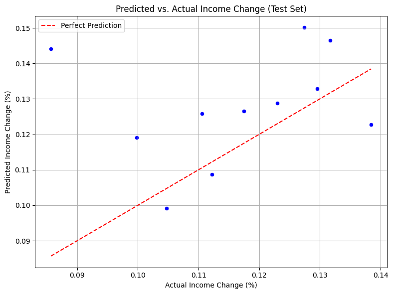

```python
import matplotlib.pyplot as plt
import seaborn as sns
import pandas as pd

truth_and_pred_test = pd.DataFrame({
    'Actual': y_test,
    'Predicted': y_pred_test
})

plt.figure(figsize=(8,6))
sns.scatterplot(data=truth_and_pred_test, x='Actual', y='Predicted', color='blue')
plt.plot([y_test.min(), y_test.max()], [y_test.min(), y_test.max()], color='red', linestyle='--', label='Perfect Prediction')
plt.xlabel('Actual Income Change (%)')
plt.ylabel('Predicted Income Change (%)')
plt.title('Predicted vs. Actual Income Change (Test Set)')
plt.legend()
plt.grid(True)
plt.tight_layout()
plt.show()
```

# Model 2

Below, is the same model, however with regional variables added in

```python
from sklearn.model_selection import train_test_split, KFold, cross_val_score
from sklearn.linear_model import LinearRegression
from sklearn.metrics import mean_absolute_error, make_scorer
import statsmodels.api as sm
import numpy as np
import pandas as pd

df = merged_percent.copy()
##same independent variables, just with region added in
X = df[['BachelorsPercentChange', 'PercentChangePop']].join(
    pd.get_dummies(df['Region'], prefix='Region', drop_first=True).astype(int)
)

y = df['income_change']

X = X.apply(pd.to_numeric, errors='coerce').dropna()
y = pd.to_numeric(y, errors='coerce')
y = y.loc[X.index]

X_train, X_test, y_train, y_test = train_test_split(
    X, y, test_size=0.2, random_state=42
)

model = LinearRegression()
kf = KFold(n_splits=5, shuffle=True, random_state=42)

mae_scores = -cross_val_score(
    model, X_train, y_train, cv=kf,
    scoring=make_scorer(mean_absolute_error, greater_is_better=False)
)

print("MAE on training sets:", -mae_scores)
print("Average MAE:", np.mean(-mae_scores))

model.fit(X_train, y_train)
y_pred_test = model.predict(X_test)
test_mae = mean_absolute_error(y_test, y_pred_test)
print(f"Test MAE: {test_mae:.6f}")

X_train_ols = sm.add_constant(X_train)
ols_model = sm.OLS(y_train, X_train_ols).fit()
print(ols_model.summary())
```

```
MAE on training sets: [-0.0139018  -0.01193776 -0.01903224 -0.01659666 -0.01794376]
Average MAE: -0.01588244318592983
Test MAE: 0.021096
                            OLS Regression Results
==============================================================================
Dep. Variable:          income_change   R-squared:                       0.566
Model:                            OLS   Adj. R-squared:                  0.503
Method:                 Least Squares   F-statistic:                     9.112
Date:                Wed, 07 May 2025   Prob (F-statistic):           1.27e-05
Time:                        18:04:35   Log-Likelihood:                 107.50
No. Observations:                  41   AIC:                            -203.0
Df Residuals:                      35   BIC:                            -192.7
Df Model:                           5
Covariance Type:            nonrobust
==========================================================================================
                             coef    std err          t      P>|t|      [0.025      0.975]
------------------------------------------------------------------------------------------
const                      0.0785      0.008      9.302      0.000       0.061       0.096
BachelorsPercentChange     0.0069      0.002      4.439      0.000       0.004       0.010
PercentChangePop           0.0062      0.002      2.539      0.016       0.001       0.011
Region_Northeast           0.0110      0.010      1.136      0.264      -0.009       0.031
Region_South               0.0194      0.008      2.294      0.028       0.002       0.037
Region_West                0.0276      0.009      3.099      0.004       0.010       0.046
==============================================================================
Omnibus:                        7.811   Durbin-Watson:                   1.769
Prob(Omnibus):                  0.020   Jarque-Bera (JB):                6.713
Skew:                           0.797   Prob(JB):                       0.0348
Kurtosis:                       4.178   Cond. No.                         19.8
==============================================================================

Notes:
[1] Standard Errors assume that the covariance matrix of the errors is correctly specified.
```

# Conclusion

As indicated by my EDA and my models, a relation exists between population growth, bachelor rates and income growth. My hyptohesis also stands, areas with higher growth in population and bachelor rates tend to have higher income growth. While both of my models are accurate, I lean towards the simpler model without regional indicators, due to the lower MAE. Based off this, we should focus on policy that increases educational oppurtunities, especially at the bachelor degree level. If you increase economic growth through focusing on education, we can assume that this will motivate people to move to your state, increasing population growth and faurther increasing income growth.

Below is some additional reading about this topic.

Paper about the relation between population growth and economic developement between countries: https://www.emerald.com/insight/content/doi/10.1108/reps-11-2022-0093/full/html

Here is a article about the relation between economic growth and education: https://www.csis.org/analysis/investing-quality-education-economic-development-peace-and-stability https://hanushek.stanford.edu/publications/education-and-economic-growth

Article about what colleges do for local economies: https://www.brookings.edu/articles/what-colleges-do-for-local-economies-a-direct-measure-based-on-consumption/

"The average bachelor degree holder contributes 278,000 more to local economies than the average high school graduate through direct spending over the course of his or her lifetime; an associate degree holder contributes 81,000 more thana a high school graduate."

Faurther shows that bachelors degrees contribute to economic growth.